# Descriptive Statistics Assignment

Your name

# Your turn!

We went through some exploratory analysis on our own, which will help us answer some questions in the data, and will actually give us more questions! Now pick another dataset from `mlbench` and create a markdown notebook of you exploring the data, following the same 5 steps.

1. Take a glimpse at your data
2. Look at the dimensions of your data
3. Look at the class types of your data
4. Distribution of your data

## Correlations in your data

Load mlbench and tidyverse

```r
library(mlbench)
library(tidyverse)
```

The package `mlbench` has a bunch of datasets that you can use to explore and build machine learning models on.

Select the dataset you’ll work with and load it using `data()`

```r
data(swiss)
```

> Since we aren’t familiar with the variables in this data, we should probably keep the explanation of these variables handy

## Explore!

1. **Take a glimpse of your data.**

```r
#view the first 6 rows
head(swiss,6)
```

|  | Fertility | Agriculture | Examination | Education | Catholic | Infant.Mortality |
| --- | --- | --- | --- | --- | --- | --- |
| Courtelary | 80.2 | 17.0 | 15 | 12 | 9.96 | 22.2 |
| Delemont | 83.1 | 45.1 | 6 | 9 | 84.84 | 22.2 |
| Franches-Mnt | 92.5 | 39.7 | 5 | 5 | 93.40 | 20.2 |
| Moutier | 85.8 | 36.5 | 12 | 7 | 33.77 | 20.3 |
| Neuveville | 76.9 | 43.5 | 17 | 15 | 5.16 | 20.6 |
| Porrentruy | 76.1 | 35.3 | 9 | 7 | 90.57 | 26.6 |

2. **Look at the dimensions of your data.**

```r
#dimensions
dim(swiss)
```

```
[1] 47  6
```

3. **Look at the class types of each variable in your data.**

```r
#class types
class(swiss)
```

```
[1] "data.frame"
```

4. **Distribution of your data**

```r
#distributions
summary(swiss)
```

```
   Fertility      Agriculture     Examination      Education        Catholic       Infant.Mortality
 Min.   :35.00   Min.   : 1.20   Min.   : 3.00   Min.   : 1.00   Min.   :  2.150   Min.   :10.80
 1st Qu.:64.70   1st Qu.:35.90   1st Qu.:12.00   1st Qu.: 6.00   1st Qu.:  5.195   1st Qu.:18.15
 Median :70.40   Median :54.10   Median :16.00   Median : 8.00   Median : 15.140   Median :20.00
 Mean   :70.14   Mean   :50.66   Mean   :16.49   Mean   :10.98   Mean   : 41.144   Mean   :19.94
 3rd Qu.:78.45   3rd Qu.:67.65   3rd Qu.:22.00   3rd Qu.:12.00   3rd Qu.: 93.125   3rd Qu.:21.70
 Max.   :92.50   Max.   :89.70   Max.   :37.00   Max.   :53.00   Max.   :100.000   Max.   :26.60
```

5. **Correlations in your data**

```r
#try the pairs() function or the cor() function from the corrplot package.
cor(swiss)
```

```
                  Fertility Agriculture Examination   Education   Catholic Infant.Mortality
Fertility         1.0000000  0.35307918  -0.6458827 -0.66378886  0.4636847       0.41655603
Agriculture       0.3530792  1.00000000  -0.6865422 -0.63952252  0.4010951      -0.06085861
Examination      -0.6458827 -0.68654221   1.0000000  0.69841530 -0.5727418      -0.11402160
Education        -0.6637889 -0.63952252   0.6984153  1.00000000 -0.1538589      -0.09932185
Catholic          0.4636847  0.40109505  -0.5727418 -0.15385892  1.0000000       0.17549591
Infant.Mortality  0.4165560 -0.06085861  -0.1140216 -0.09932185  0.1754959       1.00000000
```

> Explain these correlations is simple terms based on what you know that the variables represent.

Education and examination share a very strong correlation.

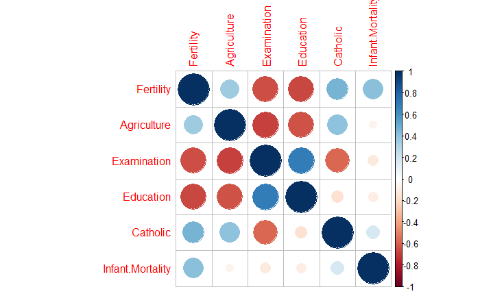

```r
swiss %>% cor() %>%
  corrplot(method = "circle")
```